# Generalists and Specialists: How Language Barriers Affect Activity Diversity on Reddit

We study how the language of user/subreddit affects GS-score. This work is an extension of Waller and Anderson's [paper](http://csslab.cs.toronto.edu/gs/actdiv-www2019.pdf) on using GS-scores to measure activity diversity on Reddit. Following the context of the paper, we will use "community" and "subreddit" interchangeably. Similarly, we will use "user" to mean a Redditor.

## Research Questions

Our work seek to describe the effect of language usage on activity diversity. Since activity diversity can be measured both on a user and on a community, this naturally leads to these two research questions:

RQ1: Do English-speaking communities tend to be more generalist than non-English-speaking communities?

RQ2: Do English-speaking users tend to be more generalist than non-English-speaking users?

## The Data

For raw data, we will use `text_comments.csv` that contains comments on Reddit from January 2019 to June 2021. This dataset includes around 40M comments across top 5000 subreddits by activity. The schema is defined as follows:

- `id`: unique id
- `link_id`: id of submission to which this comment belongs
- `score`: score of comment based on upvote and downvotes
- `author`: username of comment
- `subreddit`: name of the subreddit the comment was posted in
- `created_utc`: datetime when the comment waw posted
- `body`: text of the comment

Let's look at the first 10 rows of the dataset.

|  | id | score | link_id | author | subreddit | body | created_utc |
| --- | --- | --- | --- | --- | --- | --- | --- |
| 0 | t1_ftjl56l | 4 | t3_gzv6so | mega_trex | BeautyGuruChatter | Does anyone have a good cruelty free one? The ... | 1591755558 |
| 1 | t1_ftjpxmc | 6 | t3_gzv6so | [deleted] | BeautyGuruChatter | (stares at my soft glam i've had for like 3 ye... | 1591758382 |
| 2 | t1_gzzxfyt | 22 | t3_nodb9e | divadream | BeautyGuruChatter | When Jen’s initial reactions came out to the s... | 1622398357 |
| 3 | t1_gzzy7nc | 92 | t3_no6qaj | Ziegenkoennenfliegen | BeautyGuruChatter | I think you mean a \n>Highschool *fucking* bully | 1622398743 |
| 4 | t1_h00tpbp | 82 | t3_nolx7p | meowrottenralph | BeautyGuruChatter | Ugh. I was honestly hoping that this brand wou... | 1622414834 |
| 5 | t1_ftlamij | 1 | t3_h0an62 | somethingelse19 | BeautyGuruChatter | She's 35 in 2020\n\nhttps://jezebel.com/no-off... | 1591801024 |
| 6 | t1_h01dtz3 | 28 | t3_noo5e0 | sasukesbutt | BeautyGuruChatter | Is haus labs still around? I’m so out of the loop | 1622426299 |
| 7 | t1_h01fl3q | 2 | t3_nn2hz7 | Mika_Kyle | BeautyGuruChatter | But I thought it's all because she is oppresse... | 1622427319 |
| 8 | t1_ftll1qn | 6 | t3_h0dpxq | [deleted] | BeautyGuruChatter | This is such a mature and professional respons... | 1591807162 |
| 9 | t1_ftlsbtj | 2 | t3_h0an62 | angelicad6 | BeautyGuruChatter | Definitely 😊 | 1591810532 |

Notice that in this work we only consider user comments despite that we also have `text_submissions.csv` that contains the posts. This is because, to answer our research questions, we need to compute the GS-scores of our users. The original paper uses Reddit data from 2017 and defines GS-scores based users *commenting* in different subreddits. Therefore, to reproduce the GS-scores on our current dataset (Reddit 2019 to 2021), we will follow the same methodology and only use the comments.

## Methodology

To answer our research questions about activity diversity and languages. We need to first calculate the GS-scores (as a measure of activity diversity) and the language for each user and community.

For the computation of GS-scores, we use an additional dataset, the community embedding for Reddit from [CSSLab](https://github.com/CSSLab/social-dimensions). Since this is a separate dataset than our `text_comments.csv`, our clean data will only contain comments whose subreddits are in the community embedding dataset.

### User GS-Score

GS-score is a measure of activity diversity that is computed using a community embedding. The community embedding embeds each community into a point in a high-dimensional space where similar communities are close to each other. For any community $c_j$, we denote its embedding as $\vec{c_j}$ (normalised).

With the community embedding, we can define, for a user $u_i$ who has $w_j$ contribution to community $c_j$, the user $u_i$'s *center of mass* as:

$$ \vec\mu_i=\sum_jw_j\vec{c_j} $$

Then, user $u_i$'s activity diversity (aka GS-score) is defined as the average cosine similarity between $u_i$'s contribution to each community and their center of mass:

$$ GS(u_i) = \frac1J\sum_jw_j\frac{\vec{c_j}\cdot\vec\mu_i}{\|\vec\mu_i\|} $$

where $J$ is the number of communities that $u_i$ has contributed to.

Give our dataset on user comments, we can compute the GS-score for each user. Here is the distribution of GS-scores for our users.

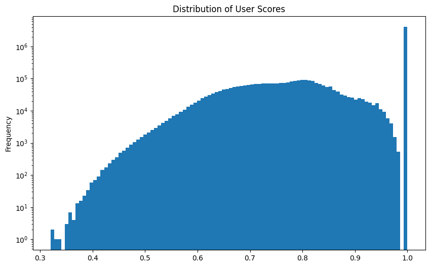

```
99.87% of user scores are between 0.5 and 1.0
```

From the historgram, we can see a very large amount of users having GS-score of 1. This occurs when a user only comments in one community.

The GS-score has a theoretical range of $[-1, 1]$. where $-1$ is extreme generalist and $1$ is extreme specialist. In our case, over 99% of users have a GS-score in the range of $0.5$ and $1$, which matches with the findings in the paper.

### Community GS-Score

The measure for community activity diversity is computed based on user GS-scores. The GS-scores of a community, $GS(c_i)$ is the average of its users' GS-scores, weighted by contribution amount:

$$ GS(c_i) = \frac1{\sum_iw_i}\sum_iw_iGS(u_i) $$

The community GS-score distribution for our dataset is as follows:

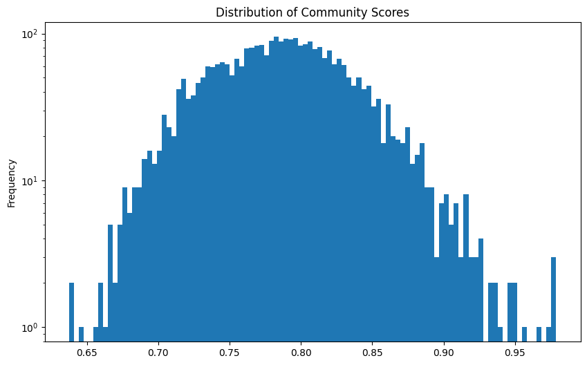

The distribution for community scores is less skewed than user scores.

### User Language

We now move to language detection. We will use [lingua](https://github.com/pemistahl/lingua-py), a language detection library suitable for short texts. We exclude comments whose language is cannot be detected. Such comments can be non-text comments (e.g. images, videos) or comments with just emojis/urls.

For a user $u_i$ and a language $L$, we define $u_i$'s *$L$ frequency* as the proportion of comments that $u_i$ has in $L$. Therefore, the higher the user's english frequency, the more likely the user is an English speaker.

Let's look at the distribution of English frequency for our users.

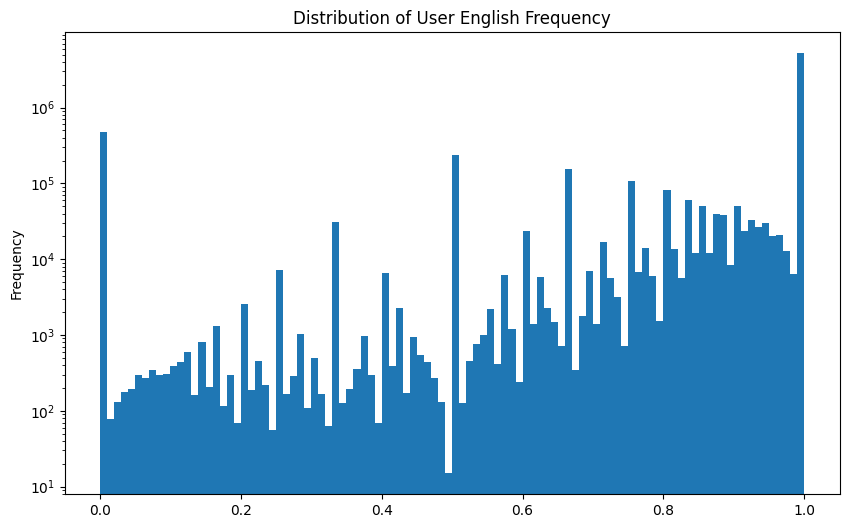

We see that there is a large amount of users with English frequency of $1$, that is, they only comment in English. The second largest bin is users with English frequency of $0$ (i.e. never comments in English)

### Community Language

Similar to user language, we can also define community language based on the comments made in the community: a community $c_i$'s frequency in language $L$ is the proportion of comments made in $c_i$ in language $L$.

Here is the distribution of English frequency for our communities.

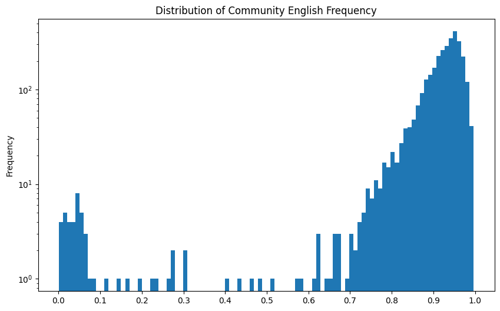

As expected, the distribution is left skewed, meaning that most communities are English-speaking. We can also verify our calculation based on some common subreddits. For instance:

```
r/france has 91.49% of comments in French
r/italy has 88.85% of comments in Italian
r/Denmark has 87.23% of comments in Danish
r/germany has 5.79% of comments in German
```

([r/germany](https://www.reddit.com/r/germany/) is about English-language discussions related to Germany.)

## Results

### RQ1

> Do English-speaking communities tend to be more generalist than non-English-speaking communities?

To answer our RQ1, we will look at the communities with the lowest English frequencies. Looking at the histogram of community English frequencies, this means that we are interested in communities with English frequency of at most $0.1$. Let's call these communities *non-English communities* and highlight them in the following scatter plot.

[interactive chart not shown]

We see that the non-English communities are spread across the right side of the plot, meaning that they tend to be more specialist than English-speaking communities. The top 5 more specialist non-English communities are:

| subreddit | cscore |
| --- | --- |
| newsokunomoral | 0.948291 |
| podemos | 0.945803 |
| ukraina | 0.905109 |
| newsokur | 0.887232 |
| Argaming | 0.880716 |

- [r/newsokunomoral](https://www.reddit.com/r/newsokunomoral/) (Japanese) is a subreddit for news in Japan
- [r/podemos](https://www.reddit.com/r/podemos/) (Spanish) is a subreddit for a Spanish politics
- [r/ukraina](https://www.reddit.com/r/ukraina/) (Ukrainian) is a subreddit, well, about Ukraine
- [r/newsokur](https://www.reddit.com/r/newsokur/) (Japanese) is a subreddit for news in Japan (another Japanese news subreddit?)
- [r/Argaming](https://www.reddit.com/r/Argaming/) (Spanish) is a subreddit for gaming in Argentina

### RQ2

> RQ2: Do English-speaking users tend to be more generalist than non-English-speaking users?

- English-speaking users: users with English as most frequent language
- non-English-speaking users: users with most frequent not being English

We can then plot the GS-score of these users against their English frequency. Since we have 7M users, we will sample 10K users for the following plot.

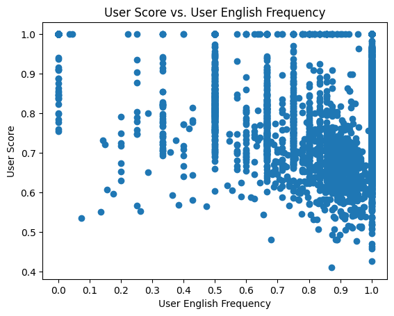

As we can see from the plot, as user English frequency increases, their GS-score tends to decrease (i.e. becoming more generalist) a little bit.

# Conclusion

We reproduced user and community GS-scores from Waller and Anderson's paper on a new Reddit dataset and studied the effect of language on activity diversity. We found a weak trend that non-English-speaking communities tend to be more specialist than English-speaking communities; the same finding applies to users as well.

We have very few data points for non-English-speaking communities and users. This is because the raw data comes from the most active subreddits, which are mostly English-speaking. Therefore, we cannot make strong conclusions about the effect of language on activity diversity. However, we can still use our findings to inform future work on language and activity diversity on Reddit.